# IODS course project

### Detecting and filtering the outlier

```r
BPRSL8S <- BPRSL %>%
  filter(week > 0) %>%
  group_by(treatment, subject, ID) %>%
  summarise( mean=mean(bprs) ) %>%
  ungroup()
# Glimpse of the data
glimpse(BPRSL8S)
```

```
## Rows: 40
## Columns: 4
## $ treatment <fct> 1, 1, 1, 1, 1, 1, 1, 1, 1, 1, 1, 1, 1, 1, 1, 1, 1, 1, 1, 1, ~
## $ subject   <fct> 1, 2, 3, 4, 5, 6, 7, 8, 9, 10, 11, 12, 13, 14, 15, 16, 17, 1~
## $ ID        <int> 1, 2, 3, 4, 5, 6, 7, 8, 9, 10, 11, 12, 13, 14, 15, 16, 17, 1~
## $ mean      <dbl> 41.500, 43.125, 35.375, 52.625, 50.375, 34.000, 37.125, 30.5~
```

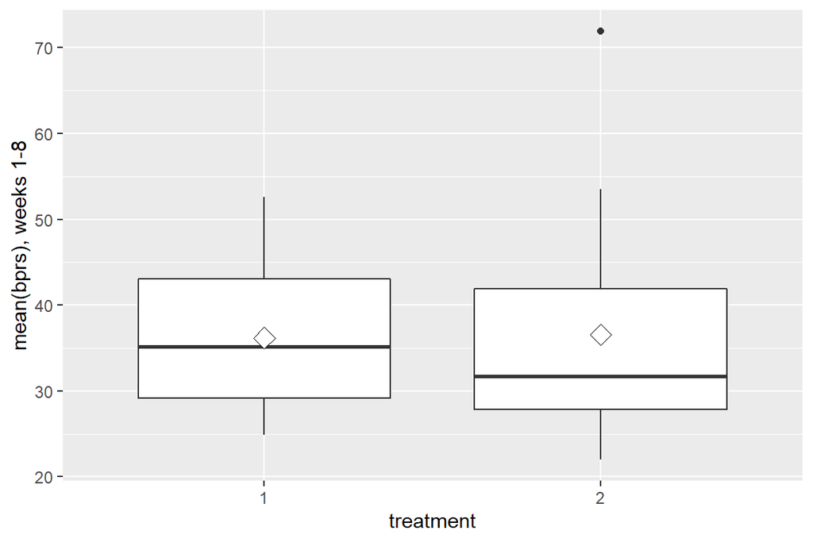

```r
# Draw a boxplot of the mean versus treatment
ggplot(BPRSL8S, aes(x = treatment, y = mean)) +
  geom_boxplot() +
  stat_summary(fun.y = "mean", geom = "point", shape=23, size=4, fill = "white") +
  scale_y_continuous(name = "mean(bprs), weeks 1-8")
```

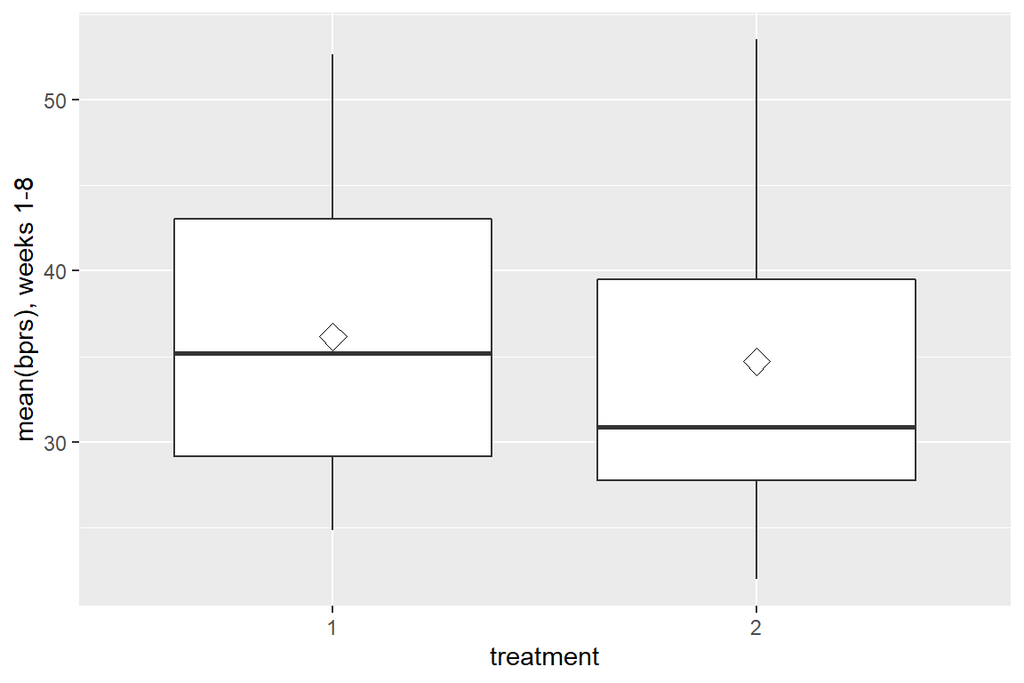

```r
# A new data by filtering the outlier
BPRSL8S1 <- BPRSL8S %>%
  filter(mean < 60)

# A boxplot 2 of the mean versus treatment
ggplot(BPRSL8S1, aes(x = treatment, y = mean)) +
  geom_boxplot() +
  stat_summary(fun.y = "mean", geom = "point", shape=23, size=4, fill = "white") +
  scale_y_continuous(name = "mean(bprs), weeks 1-8")
```

```r
# Glimpse of the data
glimpse(BPRSL8S1)
```

```
## Rows: 39
## Columns: 4
## $ treatment <fct> 1, 1, 1, 1, 1, 1, 1, 1, 1, 1, 1, 1, 1, 1, 1, 1, 1, 1, 1, 1, ~
## $ subject   <fct> 1, 2, 3, 4, 5, 6, 7, 8, 9, 10, 11, 12, 13, 14, 15, 16, 17, 1~
## $ ID        <int> 1, 2, 3, 4, 5, 6, 7, 8, 9, 10, 11, 12, 13, 14, 15, 16, 17, 1~
## $ mean      <dbl> 41.500, 43.125, 35.375, 52.625, 50.375, 34.000, 37.125, 30.5~
```

## 6.4 Linear Mixed Effects Models

The main objective in the analysis of data from a longitudinal study is to characterize change in the repeated values of the response variable and to determine the explanatory variables most associated with any change. (MABS, p. 169)

Multilevel models (also known as hierarchical linear models, linear mixed-effect model, mixed models, nested data models, random coefficient, random-effects models, random parameter models, or split-plot designs) are statistical models of parameters that vary at more than one level.They can be used as an alternative to ANCOVA (analysis of covariance), and they are able to analyze experiments without the assumptions of homogeneity-of-regression slopes (that is required by ANCOVA).” [https://en.wikipedia.org/wiki/Multilevel_model]

### A multiple linear regression model

Ignoring the repeated-measures structure of the data, a multiple linear regression model is fitted with bprs as dependent and week and treatment as explanatory variables. This model assumes independence of the repeated measures of bprs, and this assumption is highly unlikely.

The results of the model indicate, that the measurement time (week) was statistically significant explanatory variable (p<.000) for bprs scores, as the treatment group was not statistically significant (p=.661). The model explains 18% of the variation in bprs scores.

```r
BPRSL_reg <- lm(bprs ~ week + treatment, data = BPRSL)

# print out a summary of the model
summary(BPRSL_reg)
```

```
##
## Call:
## lm(formula = bprs ~ week + treatment, data = BPRSL)
##
## Residuals:
##     Min      1Q  Median      3Q     Max
## -22.454  -8.965  -3.196   7.002  50.244
##
## Coefficients:
##             Estimate Std. Error t value Pr(>|t|)
## (Intercept)  46.4539     1.3670  33.982   <2e-16 ***
## week         -2.2704     0.2524  -8.995   <2e-16 ***
## treatment2    0.5722     1.3034   0.439    0.661
## ---
## Signif. codes:  0 '***' 0.001 '**' 0.01 '*' 0.05 '.' 0.1 ' ' 1
##
## Residual standard error: 12.37 on 357 degrees of freedom
## Multiple R-squared:  0.1851, Adjusted R-squared:  0.1806
## F-statistic: 40.55 on 2 and 357 DF,  p-value: < 2.2e-16
```

### The Random Intercept Model

To begin the multilevel analysis of the BPRS data, first the random intercept model for the two explanatory variables (week & treatment) is fitted. Fitting a random intercept model allows the linear regression fit for each subject to differ in intercept from other subjects.

The first argument of lmer() function of the lme4 package is the formula object describing both the fixed-effects and random effects part of the model, with the response on the left of a ~ operator and the terms, separated by + operators, on the right. The random-effects terms distinguished by vertical bars (|).

In this model (bprs ~ week + treatment + (1 | ID)), where the week and treatment group are the fixed effects, compared to the multiple regression model, that was conducted first:

1. the standard error of the week is smaller (indicating that assuming independence will lead to the standard error of a within-subject covariate such as measurement time being larger than it should be because of ignoring the likely within-subject dependences, which will reduce the error variance in the model), and the t-value larger (incidating greater significance)
2. the the standard error of treatment group is larger, and the t-value is smaller (indicating that the significance is non-significant also in this model and even lower than in the first model)

```r
library(lme4)
library(Rcpp)

# Create a random intercept model

BPRSL_ref <- lmer(bprs ~ week + treatment + (1 | ID), data = BPRSL, REML = F)

# Print the summary of the model
summary(BPRSL_ref)
```

```
## Linear mixed model fit by maximum likelihood  ['lmerMod']
## Formula: bprs ~ week + treatment + (1 | ID)
##    Data: BPRSL
##
##      AIC      BIC   logLik deviance df.resid
##   2582.9   2602.3  -1286.5   2572.9      355
##
## Scaled residuals:
##      Min       1Q   Median       3Q      Max
## -2.27506 -0.59909 -0.06104  0.44226  3.15835
##
## Random effects:
##  Groups   Name        Variance Std.Dev.
##  ID       (Intercept) 97.39    9.869
##  Residual             54.23    7.364
## Number of obs: 360, groups:  ID, 40
##
## Fixed effects:
##             Estimate Std. Error t value
## (Intercept)  46.4539     2.3521  19.750
## week         -2.2704     0.1503 -15.104
## treatment2    0.5722     3.2159   0.178
##
## Correlation of Fixed Effects:
##            (Intr) week
## week       -0.256
## treatment2 -0.684  0.000
```

### A random intercept and random slope model

Fitting the random intercept and random slope model to the BPRS data allows the linear regression fits for each individual to differ in intercept but also in slope. This way it is possible to account for the individual differences in the bprs score profiles, but also the effect of measurement times and treatment.

The random intercept and slope model seems to provide a better ﬁt for these data: the AIC is slightly smaller, and in comparing the models (BPRSL_ref: bprs ~ week + treatment + (1 | ID), BPRSL_ref1: bprs ~ week + treatment + (week | ID)) with ANOVA the chi-squared statistic of the latter is 63.663 (df 2), with a very small p-value (1.499e-14 ***).

```r
BPRSL_ref1 <- lmer(bprs ~ week + treatment + (week | ID), data = BPRSL, REML = FALSE)

# print a summary of the model
summary(BPRSL_ref1)
```

```
## Linear mixed model fit by maximum likelihood  ['lmerMod']
## Formula: bprs ~ week + treatment + (week | ID)
##    Data: BPRSL
##
##      AIC      BIC   logLik deviance df.resid
##   2523.2   2550.4  -1254.6   2509.2      353
##
## Scaled residuals:
##     Min      1Q  Median      3Q     Max
## -2.4655 -0.5150 -0.0920  0.4347  3.7353
##
## Random effects:
##  Groups   Name        Variance Std.Dev. Corr
##  ID       (Intercept) 167.827  12.955
##           week          2.331   1.527   -0.67
##  Residual              36.747   6.062
## Number of obs: 360, groups:  ID, 40
##
## Fixed effects:
##             Estimate Std. Error t value
## (Intercept)  45.9830     2.6470  17.372
## week         -2.2704     0.2713  -8.370
## treatment2    1.5139     3.1392   0.482
##
## Correlation of Fixed Effects:
##            (Intr) week
## week       -0.545
## treatment2 -0.593  0.000
```

```r
# perform an ANOVA test on the two models
anova(BPRSL_ref, BPRSL_ref1)
```

```
## Data: BPRSL
## Models:
## BPRSL_ref: bprs ~ week + treatment + (1 | ID)
## BPRSL_ref1: bprs ~ week + treatment + (week | ID)
##            npar    AIC    BIC  logLik deviance  Chisq Df Pr(>Chisq)
## BPRSL_ref     5 2582.9 2602.3 -1286.5   2572.9
## BPRSL_ref1    7 2523.2 2550.4 -1254.6   2509.2 63.663  2  1.499e-14 ***
## ---
## Signif. codes:  0 '***' 0.001 '**' 0.01 '*' 0.05 '.' 0.1 ' ' 1
```

### Random Intercept and Random Slope Model with interaction

Finally, the ﬁt a random intercept and slope model is fitted. This model allows for a group × time interaction.

The fixed effect week*treatments t-value (1,349) is not significant. Comparison of the models (BPRSL_ref1: bprs ~ week + treatment + (week | ID), BPRSL_ref2: bprs ~ week* treatment + (week | ID)) shows, that there is no significant difference between them (chi-squared 1.78, p=0.1821). The AIC and the BIC are slightly larger in the model with interaction, so it is concluded that the random intercept and random slope model without the interaction provides a better model for the data.

```r
# create a random intercept and random slope model
BPRSL_ref2 <- lmer(bprs ~ week * treatment + (week | ID), data = BPRSL, REML = FALSE)

# print a summary of the model
summary(BPRSL_ref2)
```

```
## Linear mixed model fit by maximum likelihood  ['lmerMod']
## Formula: bprs ~ week * treatment + (week | ID)
##    Data: BPRSL
##
##      AIC      BIC   logLik deviance df.resid
##   2523.5   2554.5  -1253.7   2507.5      352
##
## Scaled residuals:
##     Min      1Q  Median      3Q     Max
## -2.4747 -0.5256 -0.0866  0.4435  3.7884
##
## Random effects:
##  Groups   Name        Variance Std.Dev. Corr
##  ID       (Intercept) 164.204  12.814
##           week          2.203   1.484   -0.66
##  Residual              36.748   6.062
## Number of obs: 360, groups:  ID, 40
##
## Fixed effects:
##                 Estimate Std. Error t value
## (Intercept)      47.8856     2.9840  16.047
## week             -2.6283     0.3752  -7.006
## treatment2       -2.2911     4.2200  -0.543
## week:treatment2   0.7158     0.5306   1.349
##
## Correlation of Fixed Effects:
##             (Intr) week   trtmn2
## week        -0.668
## treatment2  -0.707  0.473
## wek:trtmnt2  0.473 -0.707 -0.668
```

```r
# perform an ANOVA test on the two models
anova(BPRSL_ref2, BPRSL_ref1)
```

```
## Data: BPRSL
## Models:
## BPRSL_ref1: bprs ~ week + treatment + (week | ID)
## BPRSL_ref2: bprs ~ week * treatment + (week | ID)
##            npar    AIC    BIC  logLik deviance Chisq Df Pr(>Chisq)
## BPRSL_ref1    7 2523.2 2550.4 -1254.6   2509.2
## BPRSL_ref2    8 2523.5 2554.6 -1253.7   2507.5  1.78  1     0.1821
```

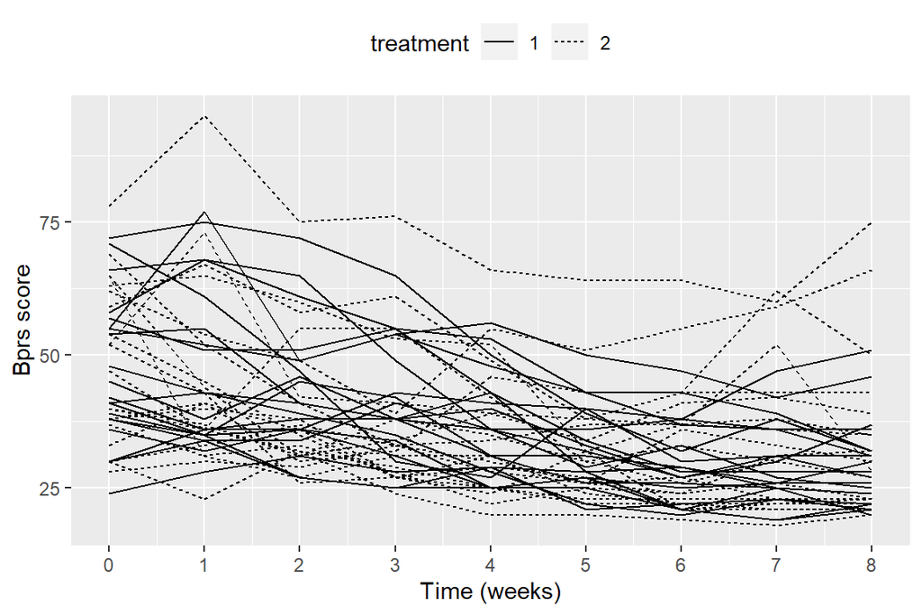

```r
#
ggplot(BPRSL, aes(x = week, y = bprs, group = ID)) +
  geom_line(aes(linetype = treatment)) +
  scale_x_continuous(name = "Time (weeks)", breaks = seq(0, 8)) +
  scale_y_continuous(name = "Bprs score") +
  theme(legend.position = "top")
```

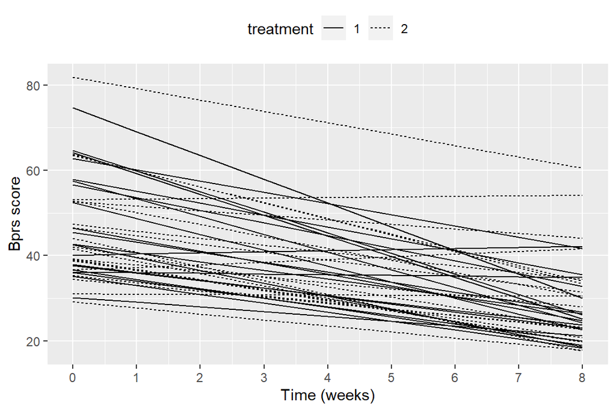

```r
# Create a vector of the fitted values
Fitted <- fitted(BPRSL_ref2)

# Create a new column fitted to RATSL
BPRSL <- BPRSL %>%
  mutate(Fitted)

# draw the plot of RATSL
ggplot(BPRSL, aes(x = week, y = Fitted, group = ID)) +
  geom_line(aes(linetype = treatment)) +
  scale_x_continuous(name = "Time (weeks)", breaks = seq(0, 8)) +
  scale_y_continuous(name = "Bprs score") +
  theme(legend.position = "top")
```